# North Carolina Public Schools Education Data

# Mini Project : Logistic Regression and Support Vector Machines

## Introduction

In our previous project, we explored the North Carolina Public High Schools Dataset and visualized how school features are correlated with college enrollment percentage. These visualizations led to several interesting assumptions regarding the relationships between school funding, school performance, school environment, teacher experience level, teacher qualification level and student performance in terms of SAT score and college enrollment percentage.

- **Question of interest**: Predict the whether or not a student will enroll in college.

For this mini-project, we will create a binary response variable with a value of 1 representing the class that a student is likely going to college and a value of 0 represents the class that the student is not likely going to college.

In this notebook we will:

1. Create a logistic regression model and a support vector machine model for the classification task defined in the question of interest above.
   - Assess how well each model performs (using 80/20 simple holdout training/testing splits).
   - Iteratively adjust parameters of the models to make them more accurate. For this use case, we feel that we have a manageable number of observations and will NOT be implementing stochastic gradient descent.
2. Discuss the advantages of each model for each classification task in terms of model prediction accuracy and training time/efficiency.
3. Use the weights from logistic regression to interpret the importance of different features for the classification task.
4. Look at the chosen support vectors for the classification task and explain how they might provide any insight into the data.

# Create Models

## 1. Library Loading & Data Preparation

- **Dataset transformation**: The orginial dataset *df_final* has two attributes for enrollment rates, *F_Female_ENROLL_sch_pct* and *M_Male_ENROLL_sch_pct* , which represent female and male students college enrollment rate accordingly. This section will load the data and combine these two variables together for analysis followed by an unpivot of the dataset by melting the table with these two atrributes as value variables and other attributes as id variabels.

The result is new dataset with double rows and an additional column for gender indicator for college enrollment. Then we create two new binary attributes for gender indicator(*binary_gender_ENROLL_sch*) and college enrollment indicator(*ENROLL_sch_pct*).

**binary_ENROLL_sch_pct** is the name of our response variable for the model.

```python
# CODE REFERENCE: https://github.com/jakemdrew/EducationDataNC
# Alteration from reference code include removal of schoolYear as these will be fixed years in the following section.

#import required Libraries
import pandas as pd
from pandas.tools.plotting import boxplot
from scipy import stats
import numpy as np
import matplotlib.pyplot as plt
import seaborn as sns
%matplotlib inline

# scikit learn package importation
from sklearn.model_selection import train_test_split
from sklearn.linear_model import LogisticRegression
from sklearn.metrics import classification_report
from sklearn.metrics import confusion_matrix
from sklearn.metrics import accuracy_score

from sklearn.svm import SVC
from sklearn.model_selection import cross_val_score
from sklearn.model_selection import KFold
from sklearn.preprocessing import StandardScaler
from sklearn.metrics import roc_auc_score
from sklearn.metrics import roc_curve
from sklearn.model_selection import ShuffleSplit
from sklearn import datasets
from sklearn.feature_selection import RFE

#**********************************************************************************
# Set the following variables before running this code!!!
#**********************************************************************************

#Location where copies of the raw data files will be downloaded and saved as csv files.
# Nuoya directory =  'C:/Conda/STUDY/data_mining/term_project/project1/HighML/'
# Phil

directory = 'C:/Conda/STUDY/data_mining/term_project/project1/HighML/'

#### Reference: Snippets of this code block was taken directly from Eric Larson git repository: https://github.com/eclarson ####
#### Reference: https://stackoverflow.com/questions/12555323/adding-new-column-to-existing-dataframe-in-python-pandas

df_2014ML = pd.read_csv(directory + 'PublicHighSchools2014_ML.csv') # read in the csv file
df_2014ML['year'] = 2014
# print('*********************************Before: 2014 Public High School Data*********************************')
# df_2014ML.info(verbose=False)

df_2015ML = pd.read_csv(directory + 'PublicHighSchools2015_ML.csv') # read in the csv file
df_2015ML['year'] = 2015
# print('*********************************Before: 2015 Public High School Data*********************************')
# df_2015ML.info(verbose=False)

df_2016ML = pd.read_csv(directory + 'PublicHighSchools2016_ML.csv') # read in the csv file
df_2016ML['year'] = 2016
# print('*********************************Before: 2016 Public High School Data*********************************')
# df_2016ML.info(verbose=False)

df_2017ML = pd.read_csv(directory + 'PublicHighSchools2017_ML.csv') # read in the csv file
df_2017ML['year'] = 2017
# print('*********************************Before: 2017 Public High School Data*********************************')
# df_2017ML.info(verbose=False)

#Combine data
#### Reference https://pandas.pydata.org/pandas-docs/stable/merging.html
df_final = pd.concat([df_2014ML,df_2015ML,df_2016ML,df_2017ML], axis=0, join='inner', ignore_index=True)
#print('*********************************After: Combined Public High School Data*********************************')
#print('*********************************Verbose=True to show all column names and type of data********************')
#df_final.info(verbose=True)

# Write to local as csv format. Commented out for now, but here as a placeholder for us to use sometimes.
#df_final.to_csv(directory + 'df_final.csv', sep=',', index=False)

print("Highschool Dataset Prepared")
```

```
Highschool Dataset Prepared
```

# Create Models

## 2. Create The Binary Response Variable

In this step, we will create the binary response of the college enrollment percentage for the future classification analysis.

```python
# describe of two response variables :F_Female_ENROLL_sch_pct,M_Male_ENROLL_sch_pct
df_final[['F_Female_ENROLL_sch_pct','M_Male_ENROLL_sch_pct']].describe().transpose()
```

|  | count | mean | std | min | 25% | 50% | 75% | max |
| --- | --- | --- | --- | --- | --- | --- | --- | --- |
| F_Female_ENROLL_sch_pct | 1904.0 | 40.513978 | 21.467421 | 0.0 | 28.163798 | 34.587017 | 53.176250 | 95.0 |
| M_Male_ENROLL_sch_pct | 1904.0 | 31.998886 | 19.458767 | 0.0 | 20.754717 | 26.884256 | 38.213056 | 95.0 |

```python
# Unpivots df_final on F_Female_ENROLL_sch_pct and M_Male_ENROLL_sch_pct
# to create a gender_college_enroll for college enrollment model

valuevar = ["F_Female_ENROLL_sch_pct","M_Male_ENROLL_sch_pct"]
idvar = list(df_final)
idvar.remove('F_Female_ENROLL_sch_pct')
idvar.remove('M_Male_ENROLL_sch_pct')

df_operation = pd.melt(df_final, id_vars = idvar,
                        value_vars=valuevar,
                        var_name='gender_college_enroll', value_name='ENROLL_sch_pct')
df_operation.info()
```

```
<class 'pandas.core.frame.DataFrame'>
RangeIndex: 3808 entries, 0 to 3807
Columns: 288 entries, student_num to ENROLL_sch_pct
dtypes: float64(265), int64(22), object(1)
memory usage: 8.4+ MB
```

In order to equalize class bias, we will split on 50% enrollment percentage.

```python
#  Binary attributes for collage enrollment of female and male.
#  binary_F_Female_ENROLL_sch_pct,binary_M_Male_ENROLL_sch_pct
#  1: Collage Enrollment Percentage greater than 50%;
#  0: Collage Enrollment Percentage less than or equal to 50%;

def f(row):
    if row['gender_college_enroll'] == 'F_Female_ENROLL_sch_pct':
        val = 1
    else:
        val = 0
    return val
df_operation['binary_gender_ENROLL_sch'] = df_operation.apply(f, axis=1)


def f(row):
    if row['ENROLL_sch_pct'] > 50:
        val = 1
    else:
        val = 0
    return val
df_operation['binary_ENROLL_sch_pct'] = df_operation.apply(f, axis=1)
```

After we create the binary response, we double check for excessive class bias below.

```python
#check for class bias based on our thresholds used.
df_operation['binary_ENROLL_sch_pct'].value_counts()
```

```
0    2970
1     838
Name: binary_ENROLL_sch_pct, dtype: int64
```

We are seeing a 3-1 class bias. This is concerning, but will run the models using the 50% split for ease of interpretation. We could downsample to match class counts, but in this mini-project we will proceed as is. We will view any simple holdout test results with caution.

Now, the binary response variable will be assigned to dataframe df_target and the features assigned to dataframe df_feat.

```python
df_target = df_operation.binary_ENROLL_sch_pct
df_feat = df_operation.drop(['binary_ENROLL_sch_pct','ENROLL_sch_pct','gender_college_enroll'], axis=1)
```

# Create Models

## 3. Feature Selection

### 3.1 Feature Selection Overview.

- The feature selection has two parts :
  - Mathematical: Recursive Feature Elimination by keeping 20 attributes from the original.
  - Domain Knowledge: Manually selected features that we consider may affect college enrollment from the following four aspects:

**1. School funding attributes:**

| Column Name | Description |
| --- | --- |
| lea_avg_student_num | Average school size within the LEA |
| lea_total_expense_num | Total expense (Dollars Spent) at LEA level |
| lea_salary_expense_pct | Percent of expense spent on Salaries at LEA level |
| lea_services_expense_pct | Percent of expense spent on Services at LEA level |
| lea_supplies_expense_pct | Percent of expense spent on Supplies at LEA level |
| lea_instruct_equip_exp_pct | Percent of expense spent on Instructional Equipment at LEA |
| lea_federal_perpupil_num | Federal expense per pupil at LEA level |
| lea_local_perpupil_num | Local expense per pupil at LEA level |
| lea_state_perpupil_num | State expense per pupil at LEA level |

**2. School performance, school environment, and student scores attributes:**

| Column Name | Description |
| --- | --- |
| SPG Score | school performace grades(numeric) |
| EVAAS Growth Score | EVVAS: provide a score to evaluate the education effectiveness |
| sat_avg_score_num | Average SAT Score (Critical Reading plus Math) at the School Level |
| sat_participation_pct | Percentage of High School Seniors taking the SAT at the School Level |
| ap_participation_pct | Percentage of High School Students taking an AP exam at the School Level |
| ap_pct_3_or_above | Percentage of Advanced Placement Exams with Scores of 3 or Above at the School Level |
| total_specialized_courses | Percent of students enrolled in at least one specialized course(CTE, AP/IB, Community College or University academic course) at the school level |
| univ_college_courses | Percent of students enrolled in at least one academic course at a community college or university at the school level |
| avg_daily_attend_pct | Average daily attendance percentage at school level |
| crime_per_c_num | Number of crimes or acts of violence per 100 students at School level |
| short_susp_per_c_num | Short term suspensions per 100 students at school level |
| long_susp_per_c_num | Long term suspensions per 100 students at School Level |
| expelled_per_c_num | Expulsions per 100 students at School Level |
| stud_internet_comp_num | Ratio of students to internet connected computer at school level |

**3. Teacher experience & qualifications attributes:**

| Column Name | Description |
| --- | --- |
| flicensed_teach_pct | Percent of teachers that meet NC fully licensed definition at school level |
| tchyrs_0thru3_pct | teaching experience year from 0-3 percentage |
| tchyrs_4thru10_pct | teaching experience year from 4-10 percentage |
| tchyrs_11plus_pct | teaching experience year 11+ percentage |
| advance_dgr_pct | Percent of teachers with masters or higher degree at school level |
| _1yr_tchr_trnovr_pct | One Year Teacher turnover percentage at school level |
| 0-3 Years_LEA_Exp_Pct_Prin | Percentage of principals at a 0-3 years of experience level at the district level |
| 10+ Years_LEA_Exp_Pct_Prin | Percentage of principals at a 10+ years of experience level at the district level |
| 4-10 Years_LEA_Exp_Pct_Prin | Percentage of principals at a 4-10 years of experience level at the district level |

**4. Minority division attributes:**

| Column Name | Description |
| --- | --- |
| GraduationRate_4yr_Female | GraduationRate 4 years for female |
| GraduationRate_4yr_Male | GraduationRate 4 years for male |
| GraduationRate_5yr_All | GraduationRate 5 years for all |
| GraduationRate_5yr_Female | GraduationRate 5 years for female |
| GraduationRate_5yr_Male | GraduationRate 5 years for male |
| GraduationRate_4yr_Asian | GraduationRate 4 years for Asians |
| GraduationRate_5yr_Asian | GraduationRate 5 years for Asians |
| GraduationRate_4yr_Black | GraduationRate 4 years for Black |
| GraduationRate_5yr_Black | GraduationRate 5 years for Black |
| GraduationRate_4yr_Hispanic | GraduationRate 4 years for Hispanic |
| GraduationRate_5yr_Hispanic | GraduationRate 5 years for Hispanic |
| GraduationRate_4yr_TwoorMoreRaces | GraduationRate 4 years for TwoorMoreRaces |
| GraduationRate_5yr_TwoorMoreRaces | GraduationRate 5 years for TwoorMoreRaces |
| GraduationRate_4yr_White | GraduationRate 4 years for White |
| GraduationRate_5yr_White | GraduationRate 5 years for White |
| GraduationRate_4yr_EDS | GraduationRate 4 years for Economically Disadvantaged |
| GraduationRate_5yr_EDS | GraduationRate 5 years for Economically Disadvantaged |
| GraduationRate_4yr_LEP | GraduationRate 4 years for Limited English Proficiency |
| GraduationRate_5yr_LEP | GraduationRate 5 years for Limited English Proficiency |
| GraduationRate_4yr_SWD | GraduationRate 4 years for Students With Disabilities |
| GraduationRate_5yr_SWD | GraduationRate 5 years for Students With Disabilities |
| GraduationRate_4yr_AIG | GraduationRate 4 years for Academically/Intellectually Gifted |
| GraduationRate_5yr_AIG | GraduationRate 5 years for Academically/Intellectually Gifted |
| MinorityFemalePct | percentage of certain subgroups, female |
| MinorityMalePct | percentage of certain subgroups, male |
| MinorityPct | percentage of certain subgroups |
| TwoOrMorePct | percentage of certain subgroups |

# Create Models

### 3.2 Recursive Feature Elimination.

**The Recursive Feature Elimination (RFE)** method is a feature selection approach. It works by recursively removing attributes and building a model on those attributes that remain. It uses the model accuracy to identify which attributes (and combination of attributes) contribute the most to predicting the target attribute.

We use RFE to select 20 explanation attributes for the model.

The final selected features are as shown:

| Column Name | Description |
| --- | --- |
| MinorityPct | percentage of certain subgroups |
| st_crime_per_c_num | Number of crimes or acts of violence per 100 students at State level |
| tchyrs_11plus_pct | teaching experience year 11+ percentage |
| lea_stud_internet_comp_num | Ratio of students to internet connected computer at LEA level |
| grade_range_cd_7-13 | Range of grades offered year 7-13, binary |
| lea_sat_participation_pct | Percentage of High School Seniors taking the SAT at the LEA Level |
| lea_tchyrs_0thru3_pct | teaching experience year from 0-3 percentage at LEA level |
| lea_ap_participation_pct | Percentage of High School Students taking an AP exam at the LEA Level |
| lea_tchyrs_4thru10_pct | teaching experience year from 4-10 percentage at LEA level |
| lea_ap_pct_3_or_above | Percentage of AP Exams with Scores of 3 or Above at the LEA Level |
| total_specialized_courses | Percent of students enrolled in at least one specialized course(CTE, AP/IB, Community College or University academic course) at the school level |
| lea_cte_courses | Percent of students enrolled in at least one Career and Technical Education (CTE) course at the LEA level |
| cte_courses | Percent of students enrolled in at least one Career and Technical Education (CTE) course at the school level |
| lea_univ_college_courses | Percent of students enrolled in at least one academic course at a community college or university at the LEA level |
| grade_range_cd_11-12 | Range of grades offered year 11-12, binary |
| lea_salary_expense_pct | Percent of expense spent on Salaries at LEA level |
| lea_1yr_tchr_trnovr_pct | One Year Teacher turnover percentage at LEA level |
| lea_emer_prov_teach_pct | In Personnel table |
| lea_advance_dgr_pct | Average percent of teachers with masters or higher degree at LEA level |
| MinorityMalePct | percentage of certain subgroups |

The following code uses RFE to select attributes.

```python
# Code reference: https://machinelearningmastery.com/feature-selection-in-python-with-scikit-learn/
# Reference: http://scikit-learn.org/stable/modules/feature_selection.html
# Recursive Feature Elimination
# This section might take a few minutes

from sklearn import datasets
from sklearn.linear_model import LogisticRegression

# create a base classifier used to evaluate a subset of attributes
model = LogisticRegression()
# create the RFE model and select attributes count that wish to keep in the model
keep_attributes = 20
rfe = RFE(model, keep_attributes)
rfe = rfe.fit(df_feat,df_target)
# summarize the selection of the attributes
# print(rfe.support_)
# print(rfe.ranking_)

# Set display parameter
#pd.set_option('display.height', 300)
#pd.set_option('display.max_rows', 300)

# Create dataframe for feature selection output.
# Selected attributes: Support = true
df_column = list(df_feat)
df_column_selection = pd.DataFrame()
df_column_selection['column']=df_column
df_column_selection['support']=rfe.support_
df_column_selection['ranking']=rfe.ranking_

print(df_column_selection.sort_values('ranking',ascending=True))
```

```
                                       column  support  ranking
257                               MinorityPct     True        1
205                        st_crime_per_c_num     True        1
209                         tchyrs_11plus_pct     True        1
203                lea_stud_internet_comp_num     True        1
268                       grade_range_cd_7-13     True        1
181                 lea_sat_participation_pct     True        1
214                     lea_tchyrs_0thru3_pct     True        1
183                  lea_ap_participation_pct     True        1
215                    lea_tchyrs_4thru10_pct     True        1
185                     lea_ap_pct_3_or_above     True        1
186                 total_specialized_courses     True        1
189                           lea_cte_courses     True        1
187                               cte_courses     True        1
190                  lea_univ_college_courses     True        1
```

[output cut: 49 more lines]

# Create Models

### 3.3 The Final Selected Features.

After obtaining the features from Recursive Feature Elimination process, we combine them with the manually selected features to create the final seleted features for future analysis.

```python
# Create dataset with auto-selected and manual-selected attributes for building logistic regression model

# auto selected columns from Logistic Regression Feature Selection
auto_selected_columns = df_column_selection.loc[df_column_selection['support'] == True]['column'].tolist()

# manually selected columns

# school features
exp_list = ['lea_total_expense_num','lea_salary_expense_pct','lea_services_expense_pct','lea_supplies_expense_pct','lea_instruct_equip_exp_pct','lea_federal_perpupil_num','lea_local_perpupil_num','lea_state_perpupil_num']

# performance scores list
school_performance = ['SPG Score','EVAAS Growth Score','sat_avg_score_num','sat_participation_pct','ap_participation_pct','ap_pct_3_or_above','total_specialized_courses','univ_college_courses','avg_daily_attend_pct','crime_per_c_num','short_susp_per_c_num','long_susp_per_c_num','expelled_per_c_num','stud_internet_comp_num']

# teacher qualifications
teachers = ['flicensed_teach_pct','tchyrs_0thru3_pct','tchyrs_4thru10_pct','tchyrs_11plus_pct','advance_dgr_pct','_1yr_tchr_trnovr_pct','0-3 Years_LEA_Exp_Pct_Prin','10+ Years_LEA_Exp_Pct_Prin','4-10 Years_LEA_Exp_Pct_Prin']

# minority division
graduation_rate = ['GraduationRate_4yr_Female','GraduationRate_4yr_Male','GraduationRate_5yr_All','GraduationRate_5yr_Female','GraduationRate_5yr_Male','GraduationRate_4yr_Asian','GraduationRate_5yr_Asian','GraduationRate_4yr_Black','GraduationRate_5yr_Black','GraduationRate_4yr_Hispanic','GraduationRate_5yr_Hispanic','GraduationRate_4yr_TwoorMoreRaces','GraduationRate_5yr_TwoorMoreRaces','GraduationRate_4yr_White','GraduationRate_5yr_White','GraduationRate_4yr_EDS','GraduationRate_5yr_EDS','GraduationRate_4yr_LEP','GraduationRate_5yr_LEP','GraduationRate_4yr_SWD','GraduationRate_5yr_SWD','GraduationRate_4yr_AIG','GraduationRate_5yr_AIG']
minority_group = ['MinorityFemalePct','MinorityMalePct','MinorityPct','TwoOrMorePct']

primary_keys = ['unit_code','year']

selected_columns = list(set().union(auto_selected_columns,exp_list,school_performance,teachers,graduation_rate,minority_group,primary_keys ))

df_feat = df_feat[selected_columns]
df_feat1 = df_feat[auto_selected_columns]
df_feat.info()
```

```
<class 'pandas.core.frame.DataFrame'>
RangeIndex: 3808 entries, 0 to 3807
Data columns (total 75 columns):
GraduationRate_5yr_Black             3808 non-null float64
tchyrs_0thru3_pct                    3808 non-null float64
GraduationRate_4yr_Black             3808 non-null float64
GraduationRate_5yr_LEP               3808 non-null float64
GraduationRate_5yr_EDS               3808 non-null float64
GraduationRate_4yr_White             3808 non-null float64
MinorityPct                          3808 non-null float64
lea_state_perpupil_num               3808 non-null float64
SPG Score                            3808 non-null float64
sat_avg_score_num                    3808 non-null float64
grade_range_cd_7-13                  3808 non-null int64
short_susp_per_c_num                 3808 non-null float64
GraduationRate_4yr_EDS               3808 non-null float64
lea_total_expense_num                3808 non-null float64
ap_participation_pct                 3808 non-null float64
avg_daily_attend_pct                 3808 non-null float64
lea_1yr_tchr_trnovr_pct              3808 non-null float64
lea_emer_prov_teach_pct              3808 non-null float64
EVAAS Growth Score                   3808 non-null float64
sat_participation_pct                3808 non-null float64
cte_courses                          3808 non-null float64
GraduationRate_5yr_Hispanic          3808 non-null float64
0-3 Years_LEA_Exp_Pct_Prin           3808 non-null float64
GraduationRate_5yr_Male              3808 non-null float64
lea_advance_dgr_pct                  3808 non-null float64
GraduationRate_5yr_TwoorMoreRaces    3808 non-null float64
tchyrs_4thru10_pct                   3808 non-null float64
lea_salary_expense_pct               3808 non-null float64
GraduationRate_5yr_Asian             3808 non-null float64
_1yr_tchr_trnovr_pct                 3808 non-null float64
lea_sat_participation_pct            3808 non-null float64
GraduationRate_5yr_SWD               3808 non-null float64
GraduationRate_4yr_TwoorMoreRaces    3808 non-null float64
GraduationRate_4yr_Hispanic          3808 non-null float64
lea_cte_courses                      3808 non-null float64
total_specialized_courses            3808 non-null float64
flicensed_teach_pct                  3808 non-null float64
```

[output cut: 25 more lines]

```
lea_stud_internet_comp_num           3808 non-null float64
GraduationRate_5yr_AIG               3808 non-null float64
lea_services_expense_pct             3808 non-null float64
MinorityMalePct                      3808 non-null float64
st_crime_per_c_num                   3808 non-null float64
tchyrs_11plus_pct                    3808 non-null float64
GraduationRate_4yr_AIG               3808 non-null float64
TwoOrMorePct                         3808 non-null float64
year                                 3808 non-null int64
expelled_per_c_num                   3808 non-null float64
lea_tchyrs_0thru3_pct                3808 non-null float64
lea_instruct_equip_exp_pct           3808 non-null float64
GraduationRate_4yr_Female            3808 non-null float64
dtypes: float64(71), int64(4)
memory usage: 2.2 MB
```

# Create Models

## 4. Training & Test Dataset Split

We used train_test_split to perform a train and test split (used 80/20 training/testing split). For this mini-project, we will use a simple holdout test set and not perform any iterative k-fold tests.

```python
from sklearn.model_selection import train_test_split
X_train, X_test, y_train, y_test = train_test_split(df_feat, df_target, test_size=0.20, random_state=3001)
```

# Create Models

## 5. Normalize The Data

We used the StandardScaler function in scikit-learn to normalize the attributes based on the mean and standard deviation of each column. Doing this will resolve problems if there are any wide range of differences in attributes.

```python
from sklearn.preprocessing import StandardScaler

# we want to normalize the features based upon the mean and standard deviation of each column.
# However, we do not want to accidentally use the testing data to find out the mean and std (this would be snooping)
# to Make things easier, let's start by just using whatever was last stored in the variables:
##    X_train , y_train , X_test, y_test (they were set in a for loop above)

# scale attributes by the training set
scl_obj = StandardScaler()
scl_obj.fit(X_train) # find scalings for each column that make this zero mean and unit std
# the line of code above only looks at training data to get mean and std and we can use it
# to transform new feature data

X_train_scaled = scl_obj.transform(X_train) # apply to training
X_test_scaled = scl_obj.transform(X_test) # apply those means and std to the test set (without snooping at the test set values)
```

# Create Models

## 6. Logistic Regression (Default vs. Fine Tuned Parameters)

We first created logistic regression model using default parameters, followed by improvements in accuracy by adding parameter selections. To accomplish the final results, we iteratively tuned the model parameters to improve the accuracy score.

We are now familiar with the knobs available to sklearn.linear_model.LogisticRegression as defined in the following link:  
http://scikit-learn.org/stable/modules/generated/sklearn.linear_model.LogisticRegression.html

```python
from sklearn.linear_model import LogisticRegression
from sklearn import metrics as mt

d_lr_clf = LogisticRegression() # Default Parameters
d_lr_clf.fit(X_train_scaled,y_train)  # train object
d_lr_y_hat = d_lr_clf.predict(X_test_scaled) # get test set predictions

d_lr_acc = mt.accuracy_score(y_test,d_lr_y_hat)
d_lr_conf = mt.confusion_matrix(y_test,d_lr_y_hat)
print('===========Logistic regression model accuracy (with default parameters)=========')
print('Accuracy:', d_lr_acc )
print('Confusion matrix:')
print(d_lr_conf[0,0], d_lr_conf[0,1])
print(d_lr_conf[1,0], d_lr_conf[1,1])
print('=================================================================================')
print

lr_clf = LogisticRegression(penalty='l1', C=.1, tol=1e-7, intercept_scaling=6, solver='liblinear') # Tuned these parameters
lr_clf.fit(X_train_scaled,y_train)  # train object
lr_y_hat = lr_clf.predict(X_test_scaled) # get test set predictions

lr_acc = mt.accuracy_score(y_test,lr_y_hat)
lr_conf = mt.confusion_matrix(y_test,lr_y_hat)
print('===========Logistic regression model accuracy (with fine tuned parameters)=======')
print('Accuracy:', lr_acc )
print('Confusion matrix:')
print(lr_conf[0,0], lr_conf[0,1])
print(lr_conf[1,0], lr_conf[1,1])
print('=================================================================================')
```

```
===========Logistic regression model accuracy (with default parameters)=========
Accuracy: 0.9343832020997376
Confusion matrix:
571 33
17 141
=================================================================================
===========Logistic regression model accuracy (with fine tuned parameters)=======
Accuracy: 0.9461942257217848
Confusion matrix:
577 27
14 144
=================================================================================
```

# Create Models

## 7. Support Vector Machines (Default vs. Fine Tuned Parameters)

We are now familiar with the knobs available to sklearn.svm.SVC as defined in the following link:  
http://scikit-learn.org/stable/modules/generated/sklearn.svm.SVC.html

```python
from sklearn.svm import SVC

d_svm_clf = SVC() # default parameters
d_svm_clf.fit(X_train_scaled, y_train)  # train object
d_svm_y_hat = d_svm_clf.predict(X_test_scaled) # get test set predictions

d_svm_acc = mt.accuracy_score(y_test,d_svm_y_hat)
d_svm_conf = mt.confusion_matrix(y_test,d_svm_y_hat)
print('===========SVM model accuracy (with default parameters)=========================')
print('Accuracy:', d_svm_acc )
print('Confusion matrix:')
print(d_svm_conf[0,0], d_svm_conf[0,1])
print(d_svm_conf[1,0], d_svm_conf[1,1])
print('=================================================================================')

svm_clf = SVC(C=1.2, kernel='rbf', probability=True, shrinking=True) # tuned these parameters
svm_clf.fit(X_train_scaled, y_train)  # train object
svm_y_hat = svm_clf.predict(X_test_scaled) # get test set predictions

svm_acc = mt.accuracy_score(y_test,svm_y_hat)
svm_conf = mt.confusion_matrix(y_test,svm_y_hat)
print('===========SVM model accuracy (with fine tuned parameters)======================')
print('Accuracy:', svm_acc )
print('Confusion matrix:')
print(svm_conf[0,0], svm_conf[0,1])
print(svm_conf[1,0], svm_conf[1,1])
print('=================================================================================')
```

```
===========SVM model accuracy (with default parameters)=========================
Accuracy: 0.9304461942257218
Confusion matrix:
572 32
21 137
=================================================================================
===========SVM model accuracy (with fine tuned parameters)======================
Accuracy: 0.9291338582677166
Confusion matrix:
572 32
22 136
=================================================================================
```

# Create Models

## 8. Assessment

As shown above, we have accuracies and confusion matrices. This chapter will close out the Create Models section by comparing the accuracies and then providing a few other terms that can be derived from the confusion matrix.

[output not shown]

Reference:http://www.dataschool.io/simple-guide-to-confusion-matrix-terminology/

The code below provides these terms for our SVM and LR final (fine tuned version) models.

```python
print('The results above show that we have a logistic regression accuracy score of ', lr_acc, 'vs. an SVM accuracy score of', svm_acc)
print
print
print('Below are some of the terms derived from confusion matrix as described above')
TN=float(svm_conf[0,0])
TP=float(svm_conf[1,1])
FN=float(svm_conf[1,0])
FP=float(svm_conf[0,1])
TPR=TP/(TP+FN)
TNR=TN/(TN+FP)
PPV=TP/(TP+FP)
NPV=TN/(TN+FN)
FNR=FN/(FN+FP)
FPR=FP/(FP+TN)
FDR=FP/(FP+TP)
FOR=FN/(FN+TN)
ACC=(TP+TN)/(TP+TN+FP+FN)
ERR=(FP+FN)/(TP+TN+FP+FN)
F1=(2*TP)/((2*TP)+FP+FN)

print('SVM TN=',TN)
print('SVM TP=',TP)
print('SVM FN=',FN)
print('SVM FP=',FP)
print('SVM TPR=',TPR)
print('SVM TNR=',TNR)
print('SVM PPV=',PPV)
print('SVM NPV=',NPV)
print('SVM FNR=',FNR)
print('SVM FPR=',FPR)
print('SVM FDR=',FDR)
print('SVM FOR=',FOR)
print('SVM ACC=',ACC)
print('SVM ERR=',ERR)
print('SVM F-score=',F1)
print
print

TN=float(lr_conf[0,0])
TP=float(lr_conf[1,1])
FN=float(lr_conf[1,0])
FP=float(lr_conf[0,1])
TPR=TP/(TP+FN)
TNR=TN/(TN+FP)
PPV=TP/(TP+FP)
NPV=TN/(TN+FN)
FNR=FN/(FN+FP)
FPR=FP/(FP+TN)
FDR=FP/(FP+TP)
FOR=FN/(FN+TN)
ACC=(TP+TN)/(TP+TN+FP+FN)
ERR=(FP+FN)/(TP+TN+FP+FN)
F1=(2*TP)/((2*TP)+FP+FN)

print('LR TN=',TN)
print('LR TP=',TP)
print('LR FN=',FN)
print('LR FP=',FP)
print('LR TPR=',TPR)
print('LR TNR=',TNR)
print('LR PPV=',PPV)
print('LR NPV=',NPV)
print('LR FNR=',FNR)
print('LR FPR=',FPR)
print('LR FDR=',FDR)
print('LR FOR=',FOR)
print('LR ACC=',ACC)
print('LR ERR=',ERR)
print('LR F-score=',F1)
```

```
The results above show that we have a logistic regression accuracy score of  0.9461942257217848 vs. an SVM accuracy score of 0.9291338582677166
Below are some of the terms derived from confusion matrix as described above
SVM TN= 572.0
SVM TP= 136.0
SVM FN= 22.0
SVM FP= 32.0
SVM TPR= 0.8607594936708861
SVM TNR= 0.9470198675496688
SVM PPV= 0.8095238095238095
SVM NPV= 0.9629629629629629
SVM FNR= 0.4074074074074074
SVM FPR= 0.052980132450331126
SVM FDR= 0.19047619047619047
SVM FOR= 0.037037037037037035
SVM ACC= 0.9291338582677166
SVM ERR= 0.07086614173228346
SVM F-score= 0.8343558282208589
LR TN= 577.0
LR TP= 144.0
LR FN= 14.0
LR FP= 27.0
LR TPR= 0.9113924050632911
LR TNR= 0.9552980132450332
LR PPV= 0.8421052631578947
LR NPV= 0.9763113367174281
LR FNR= 0.34146341463414637
LR FPR= 0.04470198675496689
LR FDR= 0.15789473684210525
LR FOR= 0.023688663282571912
LR ACC= 0.9461942257217848
LR ERR= 0.05380577427821522
LR F-score= 0.8753799392097265
```

# Model Advantages

Sources:

https://medium.com/@aneesha/recursive-feature-elimination-with-scikit-learn-3a2cbdf23fb7

https://elitedatascience.com/machine-learning-algorithms

http://www.dataschool.io/simple-guide-to-confusion-matrix-terminology/

As mentioned in the section outlining our analysis strategy, we decided to conduct a binary classification task of measuring which school features contained in the North Carolina Public High Schools dataset represented the best predictors of whether or not student graduates were likely to enroll in college-level courses using techniques such as recursive feature elimination for preprocessing and modeling our predictions leveraging logistic regression and support vector machine (SVM) techniques. Before receiving model predictions using logistic regression and SVMs, we first had to construct a binary classifier because a binary response variable was not found in the original dataset. Thus, we decided to create two new binary responses.

With regard to model advantages as well as disadvantages using classification techniques such as logistic regression and support vector machines, we did see some observable differences related to model accuracy. Before commenting on observed differences, it’s important to point out the inherent advantages and disadvantages of each technique. Although different from linear regression, logistic regression models are still “linear” in that they function well when classes are linearly separable; however, logistic regression can still be used when classes cannot be easily separated by single decision surface, but the costs from doing so results in coefficients being penalized.

Some strengths (not exhaustive) of logistic regression are that model outputs will have a good probabilistic interpretation as well as the ability to normalize in order to avoid the pitfall of overfitting. Lastly, models using logistic regression can easily be appended with new data using functions such as stochastic gradient descent or SGD. In terms of weaknesses or disadvantages though, it’s not uncommon to observe underperforming models when classification boundaries are non-linear and/or contain multiple decision boundaries. The “linear” component to logistic regression does not contain the flexibility to naturally capture relationships that are higher in complexity.

In the case of support vector machines, the primary benefit comes from kernels that are non-linear in order to model non-linear classification boundaries. Kernels are a mechanism used by support vector machines to measure distance between two observations. The goal is to maximize or find the optimal distance between the closest members which each belong to different classes. Unlike logistic regression, support vector machines provide more flexibility when classifying non-linear decision boundaries. With several kernels to choose from, SVMs are robust when it comes to risks of overfitting. The robustness of SVMs really begins to show when modeling datasets with high dimensionality. Some disadvantages are the amount of memory used in processing, tuning models become more difficult due to the number of kernels present, and scalability becomes problematic when using on larger datasets.

As stated above, we did observe and experience minor differences between the models using logistic regression and support vector machines.

# Model Advantages: Accuracy

```python
print('Logistic regression accuracy score:', lr_acc)
print('SVM accuracy score of', svm_acc)
```

```
Logistic regression accuracy score: 0.9461942257217848
SVM accuracy score of 0.9291338582677166
```

Outside of prediction accuracy, our model using logistic regression also performed better with regard to statistics such as false positive rates, specificity, and precision as indicated in earlier section.

# Model Advantages: Time

As it relates to training time or efficiency, we expect a model utilizing SVM to perform faster due to its enhanced flexibility of handling non-linear classification boundaries and/or complexity of relationships within the dataset. We also anticipated the logistic regression model to required more time to process due to the non-linearity of the model as well as the dimensionality of the dataset. We did, however, reduce the features before running these models and their %time outputs in comparison were not long enough to warrant any concern using one over the other.

```python
%time
lr_clf.fit(X_train_scaled,y_train)  # train object
lr_y_hat = lr_clf.predict(X_test_scaled) # get test set predictions
```

```
Wall time: 0 ns
```

```python
%time
svm_clf.fit(X_train_scaled, y_train)  # train object
svm_y_hat = svm_clf.predict(X_test_scaled) # get test set predictions
```

```
Wall time: 0 ns
```

# Interpret Feature Importance

### Source: https://christophm.github.io/interpretable-ml-book/logistic.html

```python
plt.rc("font", size=14)
import seaborn as sns
from sklearn import metrics as mt

sns.set(style="white")
sns.set(style="whitegrid", color_codes=True)

# Create dataframe for LR results.
zip_vars=pd.DataFrame()
zip_vars['column name']=df_feat.columns
zip_vars['weight']=lr_clf.coef_.T
# sort by weight and reset index of zip_vars
zip_vars = zip_vars.sort_values('weight',ascending=False)
zip_vars.reset_index(drop=True,inplace=True)
print(zip_vars)
```

```
                          column name    weight
0              lea_salary_expense_pct  0.951964
1              GraduationRate_5yr_All  0.720213
2              GraduationRate_5yr_AIG  0.315660
3                   MinorityFemalePct  0.225915
4               lea_ap_pct_3_or_above  0.217054
5               sat_participation_pct  0.211190
6                   tchyrs_11plus_pct  0.169234
7                     lea_cte_courses  0.165030
8                   sat_avg_score_num  0.141538
9                           SPG Score  0.140149
10            lea_emer_prov_teach_pct  0.136208
11           lea_supplies_expense_pct  0.115114
12                  ap_pct_3_or_above  0.091426
13               _1yr_tchr_trnovr_pct  0.090560
```

[output cut: 49 more lines]

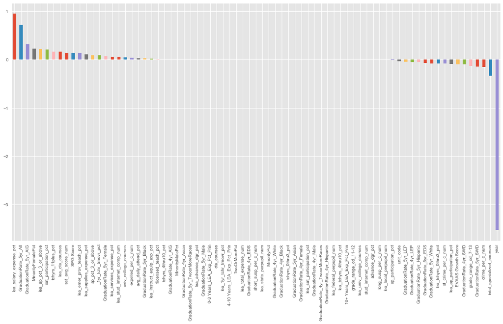

```python
# now let's make a pandas Series with the names and values, and plot them
# Sorting by series value
from matplotlib import pyplot as plt
%matplotlib inline
plt.style.use('ggplot')
plt.figure(figsize = (20,10))
# Need to update this to like the top 20
weights = pd.Series(lr_clf.coef_[0],index=df_feat.columns)
weights = weights.sort_values(ascending=False)
weights.plot(kind='bar')
plt.show()
```

# Interpret Support Vectors

Look at the chosen support vectors for the classification task. Do these provide any insight into the data? Explain.

A Support Vector Machine (SVM) is a discriminative classifier formally defined by a separating hyperplane. In other words, given labeled training data (supervised learning), the algorithm outputs an optimal hyperplane which categorizes new examples. In two dimentional space this hyperplane is a line dividing a plane in two parts where in each class lay in either side.

In simple words: **The ultimate goal of SVMs is the separation of classes.**

Reference:https://medium.com/machine-learning-101/chapter-2-svm-support-vector-machine-theory-f0812effc72

To see if these provide any insight into the data, let's look at some of the sklearn.svm.SVC attributes from our fine tuned final SVM model.

```python
# look at the support vectors
print('==========Indices of support vectors==========')
print(svm_clf.support_vectors_.shape)
print('===Number of Support Vectors for Each Class===')
print(svm_clf.n_support_ )
```

```
==========Indices of support vectors==========
(894, 75)
===Number of Support Vectors for Each Class===
[501 393]
```

As can be seen above, we now have more support vectors than initial features. Unlike linear regression, it appears we will have a difficult task to glean much information from these.

Let's go ahead and try.

Now we create a dataframe that has all the support vectors. Then create a new column named 'Likely Going' and then +add the support vectors back to the dataframe with the original data.

```python
df_support = df_operation.loc[svm_clf.support_,:] # grab the support vectors and assign it to df_support
df_support['Likely Going'] = df_target[svm_clf.support_] # add back in the 'Going' Column to the dataframe
df_operation['Likely Going'] = df_target # also add it back in for the original data
df_support.info() # there are 539 entries
df_support.head()
```

```
<class 'pandas.core.frame.DataFrame'>
Int64Index: 894 entries, 8 to 3044
Columns: 291 entries, student_num to Likely Going
dtypes: float64(265), int64(25), object(1)
memory usage: 2.0+ MB
```

|  | student_num | lea_avg_student_num | st_avg_student_num | Biology_Size | English II_Size | Math I_Size | lea_total_expense_num | lea_salary_expense_pct | lea_services_expense_pct | lea_supplies_expense_pct | ... | SPG Grade_D | EVAAS Growth Status_Met | EVAAS Growth Status_NotMet | unit_code | year | gender_college_enroll | ENROLL_sch_pct | binary_gender_ENROLL_sch | binary_ENROLL_sch_pct | Likely Going |
| --- | --- | --- | --- | --- | --- | --- | --- | --- | --- | --- | --- | --- | --- | --- | --- | --- | --- | --- | --- | --- | --- |
| 8 | 448.0 | 448.0 | 837.0 | 16.0 | 20.0 | 14.0 | 11538.34 | 0.580 | 0.080 | 0.100 | ... | 0 | 1 | 0 | 30304 | 2014 | F_Female_ENROLL_sch_pct | 79.54 | 1 | 1 | 1 |
| 20 | 148.0 | 256.0 | 837.0 | 10.0 | 18.0 | 14.0 | 11199.66 | 0.570 | 0.099 | 0.143 | ... | 0 | 1 | 0 | 80311 | 2014 | F_Female_ENROLL_sch_pct | 50.00 | 1 | 0 | 0 |
| 30 | 257.0 | 855.0 | 837.0 | 16.0 | 19.0 | 17.0 | 8380.11 | 0.647 | 0.054 | 0.071 | ... | 0 | 1 | 0 | 110322 | 2014 | F_Female_ENROLL_sch_pct | 64.28 | 1 | 1 | 1 |
| 32 | 1229.0 | 855.0 | 837.0 | 19.0 | 18.0 | 18.0 | 8380.11 | 0.647 | 0.054 | 0.071 | ... | 0 | 0 | 1 | 110340 | 2014 | F_Female_ENROLL_sch_pct | 62.12 | 1 | 1 | 1 |
| 34 | 1078.0 | 855.0 | 837.0 | 23.0 | 23.0 | 20.0 | 8380.11 | 0.647 | 0.054 | 0.071 | ... | 0 | 1 | 0 | 110380 | 2014 | F_Female_ENROLL_sch_pct | 72.89 | 1 | 1 | 1 |

5 rows × 291 columns

```python
df_operation.info()
```

```
<class 'pandas.core.frame.DataFrame'>
RangeIndex: 3808 entries, 0 to 3807
Columns: 291 entries, student_num to Likely Going
dtypes: float64(265), int64(25), object(1)
memory usage: 8.5+ MB
```

The plots below show the comparison of the support vectors(left) and the the original feature(right).

When looking at the plots of **sat_participation_pct**, the amount of 1s is bigger comparing to the original and the amount of 0s is lower.

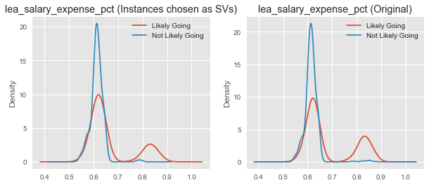

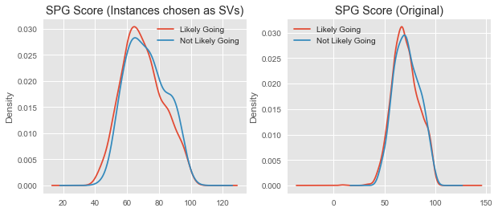

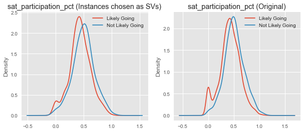

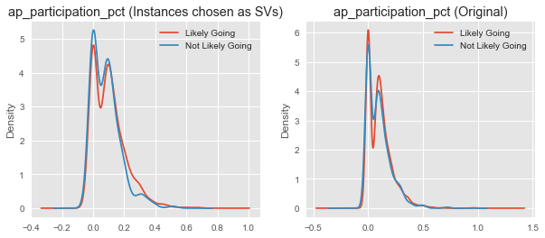

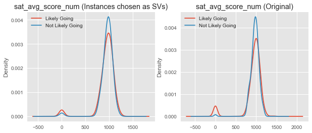

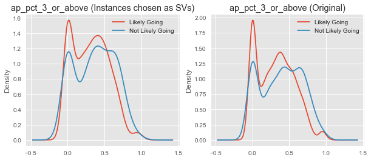

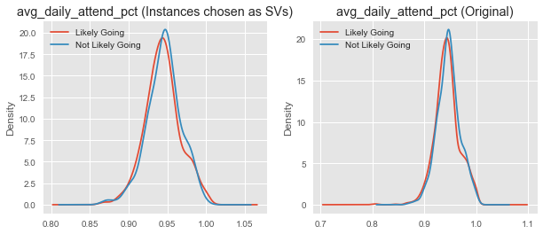

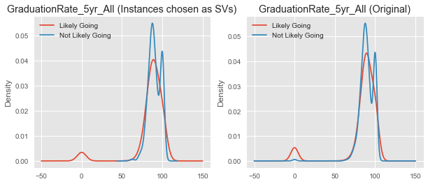

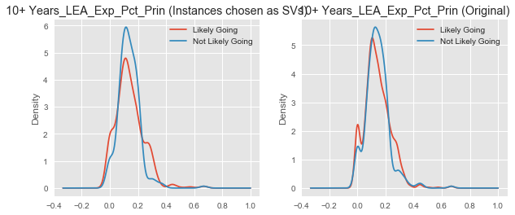

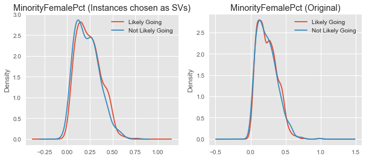

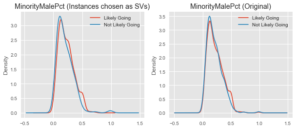

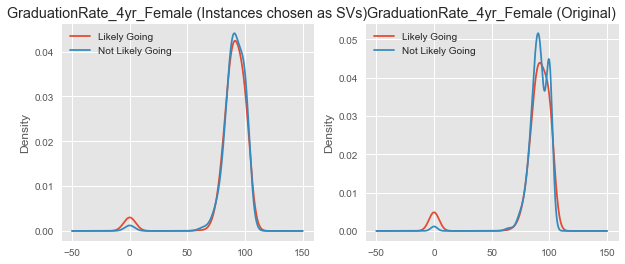

[2 more figures not shown]

```python
# Code reference this template was acquired from MSDS 7331 notes
# group the original data and the support vectors
df_grouped_support = df_support.groupby(['Likely Going'])
df_grouped = df_operation.groupby(['Likely Going'])

# plot KDE of Different variables
vars_to_plot = ['lea_salary_expense_pct','SPG Score','sat_participation_pct','ap_participation_pct',
                'sat_avg_score_num','ap_pct_3_or_above','avg_daily_attend_pct',
                'GraduationRate_5yr_All','10+ Years_LEA_Exp_Pct_Prin','MinorityFemalePct','MinorityMalePct',
                'GraduationRate_4yr_Female','GraduationRate_4yr_Female','year']

for v in vars_to_plot:
    plt.figure(figsize=(10,4))
    # plot support vector stats
    plt.subplot(1,2,1)
    ax = df_grouped_support[v].plot.kde()
    plt.legend(['Likely Going','Not Likely Going'])
    plt.title(v+' (Instances chosen as SVs)')

    # plot original distributions
    plt.subplot(1,2,2)
    ax = df_grouped[v].plot.kde()
    plt.legend(['Likely Going','Not Likely Going'])
    plt.title(v+' (Original)')
```

Interpreting support vectors appears to be much more of a struggle than interpreting logistic regression features as many of the density graphs appear to be very similar.

## Conclusion

Initially, we pared down the attributes using RFE combined with domain knowledge of expected important features. Using this data set, we trained logistic regression and SVM models to determine binary classification whether or not a student is likely going to college.

We have gained insight on how to tune model parameters, and assess how each model performs using holding training/testing splits. We are aware of the expected model differences and can see where this information would be useful when attempting to model with larger data sets.

We have learned the model interpretation differences and would likely learn towards logistic regression model in this regard.

Our efficiency hurdles were mainly due to the large number of variables and the feature elimination task was what slowed down our code. In the future we would likely pickle(serialize) the object to save time in future testing (which we assume could also be applied to longer running models).